# Estimating a CRRA utility function in R and Stan

James R Bland (https://sites.google.com/site/jamesbland/)

September 20, 2019

In 2010, at the end of my honors year in economics at the University of Melbourne, I attended my first economics seminar. Glenn Harrison presented some of his work on time preferences. This was also the first time I was introduced to structural econometrics in experiments, and so began my love for this relatively small sub-field of economics that I am now privileged to be employed to do.

Anyway, in this post I will be showing you how to estimate a constant relative risk aversion (CRRA) utility function (really the *parameter* in the function) in Stan. A lot of the applications of structural estimation to experiments are in decision-making under risk, and so while there are certainly a lot of models for how people make choices in this environment, we usually start with Expected Utility Theory as a baseline, and use the CRRA specification when we have to pick a functional form.

## Data

I am using freely available data from the following economic experiment:

> Harrison, Glenn W., and E. Elisabet Rutstrom. “Expected utility theory and prospect theory: One wedding and a decent funeral.” Experimental economics 12, no. 2 (2009): 133.

You can download the data from Glenn Harrison’s website (https://cear.gsu.edu/gwh/) here: http://cear.gsu.edu/files/2013/05/One-Wedding-and-a-Decent-Funeral1.zip. In particular, all we need is the Stata file `tmpLOTTERY.dta`. This contains *a lot* of information that we won’t need, but I will show you the important bits for the first person to appear in the data here.

```r
rm(list=ls())
library(ggplot2)
library(foreign)
library(gganimate)
library(latex2exp)
FullData <- read.dta("../Structural_Individual/tmpLOTTERY.dta")
# HR drop these observetions at the start of their lottery_Wedding.do file
  FullData<-FullData[FullData$core==1,]
idList<-unique(FullData$id)


ii<-idList[1]

  DataI<-FullData[FullData$id==ii,]

  PL<-as.matrix(data.frame(DataI[,c("P0left","P1left","P2left","P3left")]))
  PR<-as.matrix(data.frame(DataI[,c("P0right","P1right","P2right","P3right")]))
  L<-as.vector((as.integer(DataI$choice=="L")))
  N<-length(L)
```

Here we have probabilities for four prizes in a “left lottery” (each row is one lottery):

```r
  PL[1:5,]
```

```
##     P0left P1left P2left P3left
## 1     0.00   0.13   0.87   0.00
## 137   0.13   0.00   0.87   0.00
## 169   0.00   0.13   0.74   0.13
## 390   0.75   0.00   0.00   0.25
## 416   0.25   0.50   0.25   0.00
```

probabilities for prizes in a “right lottery”:

```r
  PR[1:5,]
```

```
##     P0right P1right P2right P3right
## 1      0.00    0.25     0.5    0.25
## 137    0.25    0.00     0.5    0.25
## 169    0.00    0.25     0.5    0.25
## 390    0.38    0.62     0.0    0.00
## 416    0.13    0.87     0.0    0.00
```

and the binary choices (1=left, 0=right):

```r
  L[1:5]
```

```
## [1] 0 0 1 1 1
```

All lotteries were over prizes $0, $5, $10, and $15 (integrating the show-up fee). For example, the first row of the right lottery above places 25% probability on $5 and $15, and 50% probability on $10.

## The model

I am going to estimate a constant relative risk aversion (CRRA) utility function for every subject. That is, subjects choose action $a$ to maximize:
$$E\left(X^r \mid a\right),\quad r>0$$
Here I also normalize payoffs so they are always between zero and one, so $X$ is the prize divided by $15.

However we can’t assume that they do this perfectly all the time. There are two reasons for this. Firstly, people make mistakes, and so while it is reasonable to assume that people choose the lottery that maximizes $E\left(X^r \mid a\right)$ more often than not, it is unlikely that they will do it all of the time. Also, perhaps $E\left(X^r \mid a\right)$ is actually not what they are maximizing, and so there is a component of their utility function that I (the econometrician) does not observe, but the decision-maker does. Either way, if I don’t specify a *probabilistic* decision rule, rather than a deterministic one, then my likelihood is going to be zero everywhere, and so I can’t simulate the posterior distribution (or maximize the likelihood, if I so feel the urge). The most popular specification for this for discrete choice experiments like this one is the logistic choice rule, also called softmax:
$$\Pr\left(a \right) \propto \exp\left(\lambda E\left(X^r \mid a\right)\right)$$
Which for a binary choice experiment like this one means that the probability of choosing the left lottery is:
$$\Pr\left(L=1\right)=\frac{\exp\left(E\left(X^r \mid L=1\right)\right)}{\exp\left(E\left(X^r \mid L=1\right)\right)+\exp\left(E\left(X^r \mid L=0\right)\right)}$$
Which looks like this:

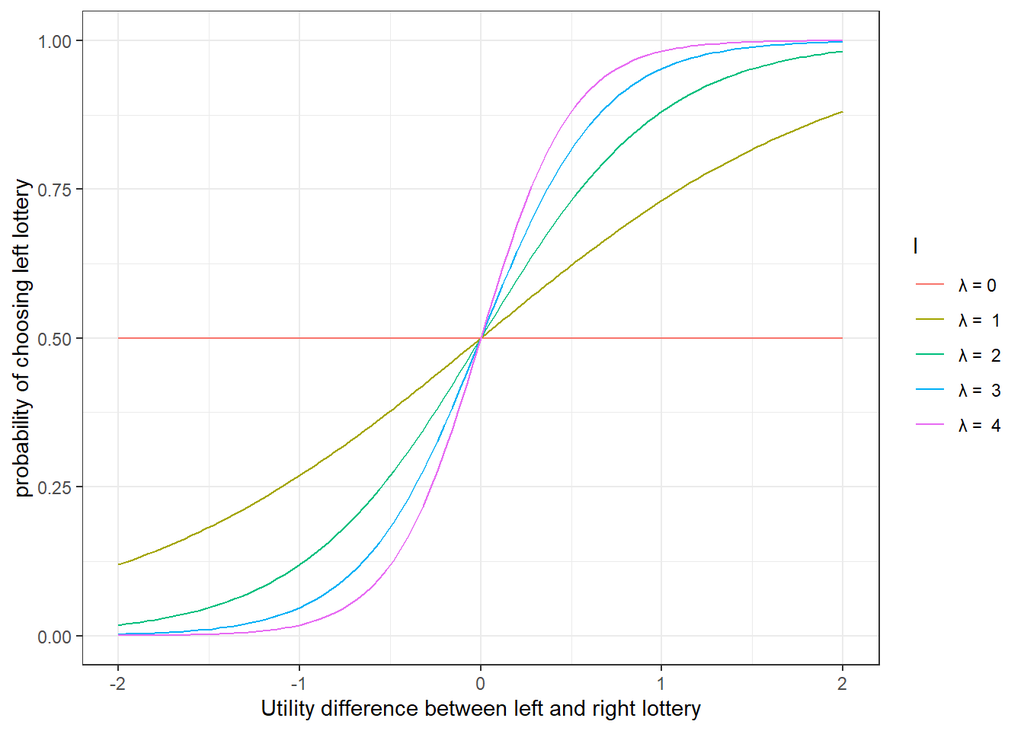

```r
DU<-seq(-2,2,length=101)
LL<-c(1,2,3,4)
l<-rep("\u03BB = 0",length(DU))
pr<-exp(0)/(exp(0)+1)
pltData<-data.frame(DU,l,pr)
for (ll in 1:length(LL)) {
  l<-rep(paste("\u03BB = ", LL[ll]),length(DU))
  pr<-exp(LL[ll]*DU)/(exp(LL[ll]*DU)+1)
  pltData<-rbind(pltData,data.frame(DU,l,pr))
}
plt<-ggplot(data=pltData,aes(x=DU,y=pr, color=l))+geom_line()+theme_bw()
plt<-plt+xlab("Utility difference between left and right lottery")+ylab("probability of choosing left lottery")
plt
```

That is, $\lambda$ measures the decision-maker’s sensitivity to payoffs.

### Likelihood

At this point, I have written down enough information to compute the likelihood function. In particular, if $p^L_{k,t}$ and $p^R_{k,t}$ are the probabilities of receiving prize $x_k$ in the left and right lotteries in decision $t$, respectively, then the log-likelihood function is:
$$\log p(Y \mid r,\lambda) = \sum_{t=1}^T\log\left(\frac{\exp(\lambda U^{y_t}_{t})}{\exp(\lambda U^L_{t})+\exp(\lambda U^R_{t})}\right)$$
where:
$$U_t^L = \sum_{k=1}^4p_k^Lx_k^r$$
And $y_t\in\{L,R\}$ is the subject’s choice for decision $t$.

However, note that in Stan we specify this as the distribution, rather than the probability, so the following statemnet is actually what Stan needs:
$$y_i\sim\mathrm{Bernoulli}\left(\frac{\exp(\lambda U^{y_t}_{t})}{\exp(\lambda U^L_{t})+\exp(\lambda U^R_{t})}\right)$$
Or even better, we can specify this as the latent index, which avoids the problem of asking our computer to unecessarily calculate $\exp(\text{a large number})$:
$$y_i\sim\mathrm{Bernoulli\_logit}\left(\lambda\left(U_t^L-U_t^R\right)\right)$$

### Priors

The parameters in my model are $r$ and $\lambda$, both of which must be positive real numbers. The log-normal distribution imposes this restriction, and gives us two free parameters to assign our priors.

We (and Harrison & Rutstrom in 2009) already know a lot about the distribution of this parameter from past experiments. So here I am going to use some information from

> Holt, Charles A., and Susan K. Laury. “Risk aversion and incentive effects.” American economic review 92, no. 5 (2002): 1644-1655.

In their “low real” treatment (see their Table 3), approximately 34% of subjects were risk loving or risk neutral ($r\geq 1$ in my parameterization), and that the median $r$ was about 0.6 (again, using my parameterization). If I use a log-normal prior,
$$\log r \sim N(\mu_r,\sigma_r)$$
I can target both of these features of the distribution. I can target the median by setting $\mu_r=\log(0.6)$. For the fraction that is risk-loving, I need to solve:
$$\begin{aligned}
1-0.34&=\Phi\left(\frac{1-\mu_r}{\sigma}\right)\\
\frac{1-\mu_r}{\sigma} &=\Phi^{-1}(1-0.34)\\
\sigma &=\frac{1-\mu_r}{\Phi^{-1}(1-0.34)}
\end{aligned}$$

```r
(1-log(0.6))/qnorm(1-0.34)
```

```
## [1] 3.662935
```

For $\lambda$, I assign another log-normal prior, but think about this in terms of how likely a subject is to choose the optimal action when there is a normalized utility difference of 0.1 (which is 10% of the range that it could take on). If $\log\lambda \sim N(\mu_\lambda,\sigma_\lambda)$, then the median probability of choosing this optimal action is $1/(1+\exp(-0.1\exp(\mu_\lambda)))$

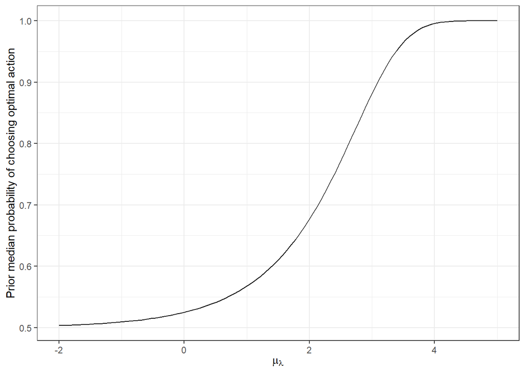

```r
muL<-seq(-2,5,length=101)
pr<-1/(1+exp(-0.1*exp(muL)))
d<-data.frame(muL,pr)
plt<-ggplot(data=d,aes(x=muL,y=pr))+geom_line()+theme_bw()
plt<-plt+xlab(TeX("$\\mu_\\lambda$"))+ylab("Prior median probability of choosing optimal action")
plt
```

$\mu_\lambda\approx 2.63$ gets this median probability to about 80%. Now holding this constant, how does the distribution of this probability change with $\sigma_\lambda$?

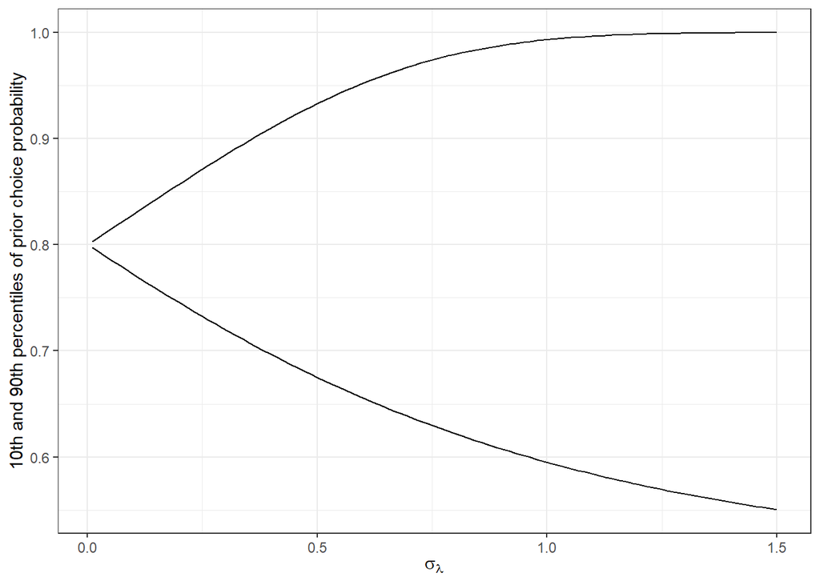

```r
sL<-seq(0.01,1.5,length=101)
prob1<-1/(1+exp(-0.1*exp(2.63+qnorm(0.1)*sL)))
prob2<-1/(1+exp(-0.1*exp(2.63+qnorm(0.9)*sL)))
d<-data.frame(sL,prob1,prob2)
plt<-ggplot(data=d)+geom_line(aes(x=sL,y=prob1))+geom_line(aes(x=sL,y=prob2))+theme_bw()
plt<-plt+xlab(TeX("$\\sigma_\\lambda$"))+ylab("10th and 90th percentiles of prior choice probability")
plt
```

## Coding up the model in Stan

```r
print(readLines("../Structural_Individual/HR2009.stan"), quote=FALSE)
```

```
##  [1] // HR2009.stan
##  [2] functions {
##  [3]    // User-defined functions go here. I don't have any for this application
##  [4]
##  [5] }
##  [6] data {
##  [7]   // Tell Stan how to read in the data
##  [8]   int<lower=0> N; // Number of observations
##  [9]   real<lower=0,upper=1> PL[N,4]; // Left lottery
## [10]   real<lower=0,upper=1> PR[N,4]; // Right lottery
## [11]   int<lower=0,upper=1>  L[N]; // Choices (1=left)
## [12]   real<lower=0> prizes[N,4]; // prizes from lotteries
## [13]
## [14] }
## [15] transformed data {
```

[output cut: 34 more lines]

## Estimating the model in RStan

```r
# HR2009.R
rm(list=ls())
setwd("C:/Users/jbland/OneDrive - University of Toledo/General notes on structural Bayes/Structural_Individual")
library(foreign)
library(xtable)
library(ggplot2)
library(gganimate)
library("rstan") # observe startup messages
rstan_options(auto_write = TRUE)
Sys.setenv(LOCAL_CPPFLAGS = '-march=native')
options(mc.cores = parallel::detectCores())



FullData <- read.dta("tmpLOTTERY.dta")

# HR drop these observetions at the start of their lottery_Wedding.do file
FullData<-FullData[FullData$core==1,]

idList<-unique(FullData$id)


for  (kk in 1:length(idList)) {

  ii<-idList[kk]

  DataI<-FullData[FullData$id==ii,]
  drop<-is.na(DataI$Choices)
  DataI<-DataI[drop==FALSE,]
  PL<-as.matrix(data.frame(DataI[,c("P0left","P1left","P2left","P3left")]))
  PR<-as.matrix(data.frame(DataI[,c("P0right","P1right","P2right","P3right")]))
  frame<-DataI$Frame
  prizes<-data.frame(DataI[,c("prize0","prize1","prize2","prize3")])
  # normalizes prizes

  prizes<-prizes-min(prizes)
  prizes<-prizes/max(prizes)


  prizes<-as.matrix(prizes)

  L<-as.vector((as.integer(DataI$choice=="L"))) #as.vector(1-(as.integer(DataI$Choices)))
  N<-length(L)

  if  (sum(as.numeric(is.na(PL))) >0 ) {}
  else {
  S<-stan("HR2009.stan")

  s<-summary(S)
  r<-s$summary["r","mean"]
  l<-s$summary["l","mean"]
  D<-data.frame(idList[kk],r,l,frame[1])
  if (kk==1) {
    RLambda<-D
  }
  else {

    RLambda<-rbind(RLambda,D)
  }

  print(paste(kk,"of",length(idList)))
  }
}
colnames(RLambda)<-c("id","r","lambda","Frame")
write.csv(RLambda,file="HR2009means.csv")
```

## The results

The above script extracts the posterior means of $r$ and $\lambda$ from the Stan fits. In later examples, I want to show how we can use all of the posterior draws, rather than just sample means, to calculate posterior moments of non-linear transforms of the model’s parameters. It is often quite computationally intensive to do the frequentist equivalent of this (e.g. bootstrapped standard errors), but once we have the posterior simulation of the parameters, getting posterior moments of any function of the parameters is very easy.

So for now I will show you two plots. The first shows the relationship between the two parameters, and the second shows how the distribution of $r$ changes with the framing of the decisions. Harrison & Rutstrom varied the framing by subtracting fixed amounts from the payoffs for some subjects, then adding in a larger show-up fee so they didn’t go bankrupt. Note that risk aversion typically increases (i.e. smaller $r$) as we move into the gains domain, which is consistent with Prospect Theory behavior (risk averse for gains, risk-loving for losses)

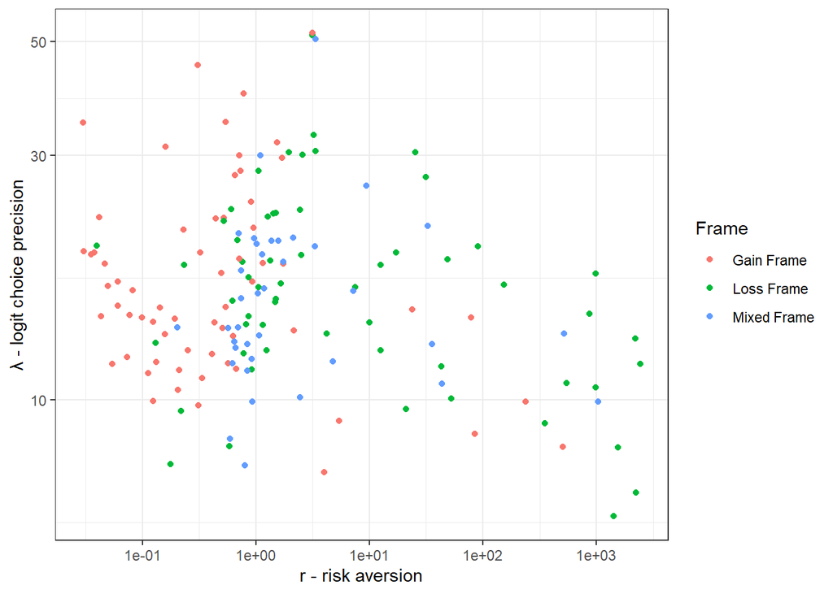

```r
# HR2009_plots.R
rm(list=ls())
setwd("C:/Users/jbland/OneDrive - University of Toledo/General notes on structural Bayes/Structural_Individual")
RLambda<-data.frame(read.csv(file="HR2009means.csv"))
colnames(RLambda)<-colnames(RLambda)<-c("row","id","r","lambda","Frame")

f<-ggplot(data=RLambda,aes(x=r,y=lambda,color=Frame))+geom_point()+scale_x_continuous(trans='log10')+scale_y_continuous(trans='log10')+theme_bw()
f<-f+xlab("r - risk aversion")+ylab("\u03BB - logit choice precision")
f
```

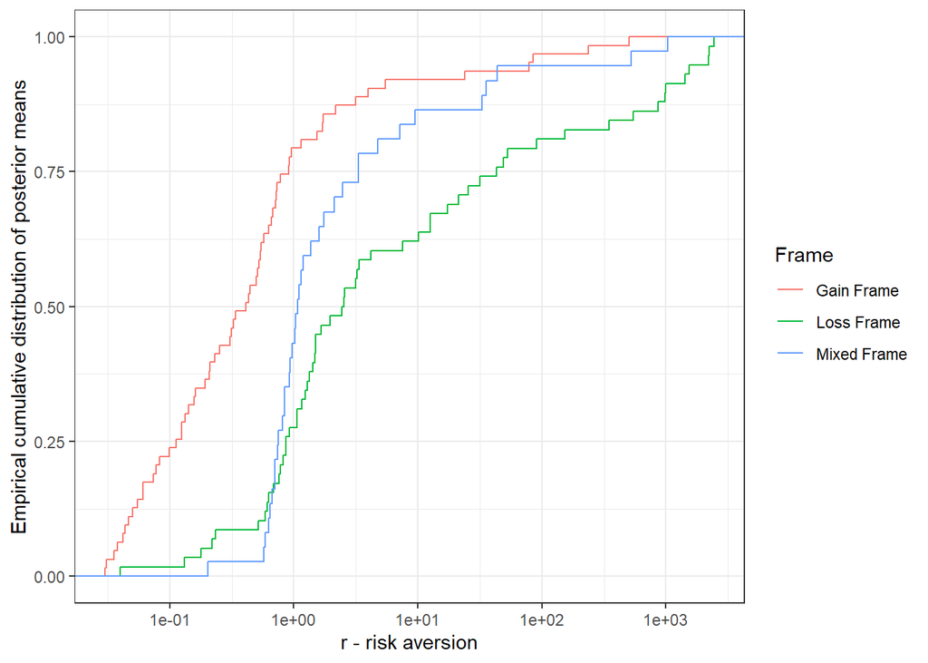

```r
h<-ggplot(data=RLambda[,],aes(x=r,color=Frame))+stat_ecdf()+scale_x_continuous(trans='log10')+theme_bw()
h<-h+ylab("Empirical cumulative distribution of posterior means")+xlab("r - risk aversion")
h
```